# Homework 5

Olivier Binette, Jae Hyun Lee, Vidvat Ramachandran

10/17/2019

# Task 1

We scrape the data from the Wawa store in the following way:

1. we consider all possible store URLs;
2. we check if they are valid by considering if the status code `HEAD(url)$status_code` corresponds to a 404 error, using the package `httr`;
3. if they are valid, we then read their content using the function `read_json` from the package `jsonlite` and store in a list.

This is implemented in the script `get_wawa.R`. The data is kept in this raw form, in the file `wawa/wawa.rds`, as to ensure completeness.

For the purpose of Task 3, we also recover geographic information in the script `parse_wawa.R`. We get the state name as well as longitude and latitude coordinates for each of the stores. This is saved as a dataframe in the file `wawa/wawa_geo_df.rds`.

# Task 2

Here we do the following:

1. we recover the list of urls from the base webpage;
2. for each of the URLs, we extract the body text and parse it as a JSON file, after replacing double square brackets for single square brackets;
3. this is stored in a list.

For Task 3, we recover state names, longitude and latitude coordinates for each of the stores. This is saved as a dataframe in the file `sheetz/sheetz_geo_df.rds`

# Task 3

### Libraries

```r
library(tidyverse)
library(mapdata)
library(maps)
library(alphahull)
library(mapview)
```

### Geographic information

Getting location data.

```r
sheetz_df = readRDS("data/sheetz/sheetz_geo_df.rds")
wawa_df = readRDS("data/wawa/wawa_geo_df.rds")
```

We now combine the wawa and sheetz data in a single dataframe, selecting only Pennsylvania stores.

```r
PA_stores = bind_rows(
  wawa_df %>% mutate(store="Wawa"),
  sheetz_df %>% mutate(store="Sheetz")
) %>% filter(state == "PA")
```

### Plotting the store locations.

We first get the state and county map data.

```r
state = map_data("state") %>% subset(region == "pennsylvania")
counties = map_data("county") %>% subset(region == "pennsylvania")
```

This provides a base map layer over which we can represent the store locations.

Below we also compute which kind of stores (Wawa or Sheetz) each of the county in Pensylvania contain. This is used to fill the counties with different colors.

```r
counties_list = counties %>% select(subregion) %>% unique()

counties_polygons = lapply(counties_list$subregion, function(county) {
  mapview::coords2Polygons(as.matrix(counties %>%
                   filter(subregion == county) %>%
                   select(x=long, y=lat)), ID="test"
                 )
})

wawa_pts = sp::SpatialPoints(
    PA_stores %>%
    filter(store=="Wawa") %>%
    select(x=longitude, y=latitude)
  )

sheetz_pts = sp::SpatialPoints(
    PA_stores %>%
    filter(store=="Sheetz") %>%
    select(x=longitude, y=latitude)
  )

contains_wawa = 1*sapply(counties_polygons, function(poly) {
  sum(!is.na(sp::over(wawa_pts, poly))) > 0
})

contains_sheetz = 2*sapply(counties_polygons, function(poly) {
  sum(!is.na(sp::over(sheetz_pts, poly))) > 0
})
```

```r
fill_df = data.frame(fill=factor(contains_wawa + contains_sheetz), subregion=counties_list)
counties = left_join(counties, fill_df, by="subregion")
```

Our ggplot theme.

```r
# hw3 - Group Leopard(Vidvat was in it) - creates an empty looking theme
ditch_the_axes <- theme(
  axis.text = element_blank(),
  axis.line = element_blank(),
  axis.ticks = element_blank(),
  panel.background = element_blank(),
  panel.border = element_blank(),
  panel.grid = element_blank(),
  axis.title = element_blank()
  )
```

Base map layer.

```r
basemap = ggplot() +
geom_polygon(data=state, mapping=aes(x = long, y = lat, group=group), size=0.5, color = "black", fill="white") +
  geom_polygon(data = counties, mapping = aes(x = long, y = lat,
                                              group=group, fill=fill), color = "black", size = 0.1) +
  scale_fill_manual(values=adjustcolor(c("white", "turquoise","red", "yellow"), alpha.f=0.2),
                    labels = c("None", "Wawa", "Sheetz", "Both Sheetz and Wawa"), name = "Counties") +
  coord_fixed(1.3) +
  ditch_the_axes
```

We finally plot the stores over the base map.

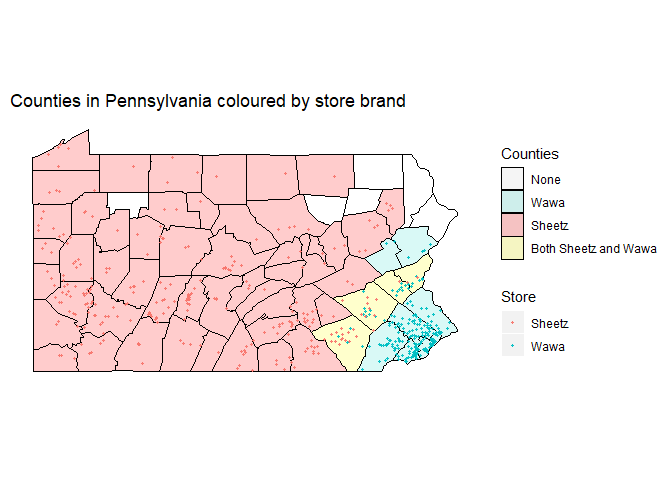

```r
map = basemap +
  geom_point(data=PA_stores,
             mapping=aes(x = longitude, y = latitude, color=store),
             alpha=0.9,
             size=0.7) +
  labs(title = "Counties in Pennsylvania coloured by store brand", color = "Store" )

map
```

We observe a dominance of Sheetz stores in the rural areas, whereas Wawa dominates around Philadelphia. The conflicting counties are Lancaster, Berks, Lehigh and Northampton, where both brands have stores.

# Appendix

We had also considered the following visualization.

```r
# fortify method for ashape(for plotting in ggplot)
# https://stackoverflow.com/questions/33304889/filling-alphahull-with-ggplot2, User : hrbrmstr
fortify.ashape <- function(ashape_res) {
 xdf <- data.frame(ashape_res$edges)
 xdf <- do.call(
   rbind,
   lapply(1:nrow(xdf), function(i) {
     rbind(
       data.frame(x=xdf$x1[i], y=xdf$y1[i]),
       data.frame(x=xdf$x2[i], y=xdf$y2[i])
     )
   })
 )
 xdf <- xdf[order(-1 * atan2(
   xdf$y - mean(range(xdf$y)),
   xdf$x - mean(range(xdf$x)))), c("x", "y")]
 xdf <- rbind.data.frame(xdf[nrow(xdf),], xdf[1:(nrow(xdf)-1),])
 xdf
}
```

```r
# creates boundary enclosing wawa stores(like a convex hull)
wawa_bd <- wawa_df %>%
  filter(state == "PA") %>%
  select(longitude, latitude)

names(wawa_bd) <- c("x", "y")
wawa_bd = ashape(wawa_bd, alpha = 2)
```

```r
# creates boundary enclosing sheetz stores
sheetz_bd <- sheetz_df %>%
  filter(state == "PA") %>%
  select(longitude, latitude)

names(sheetz_bd) <- c("x", "y")
sheetz_bd = ashape(sheetz_bd, alpha = 2)
```

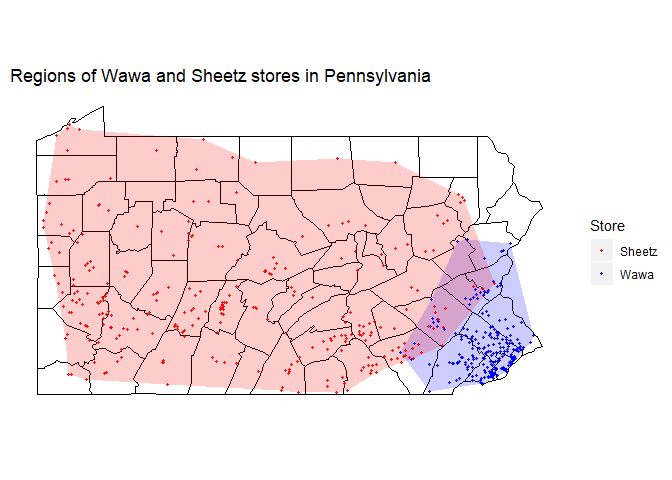

```r
# plot regions(filled boundaries) for wawa and sheetz
ggplot() +
geom_polygon(data=state, mapping=aes(x = long, y = lat, group=group), size=0.5,
             color = "black", fill="white") +
  geom_polygon(data = counties, mapping = aes(x = long, y = lat, group=group), color = "black",
               fill = "white", size = 0.1) +
  coord_fixed(1.3) + ditch_the_axes +
  geom_polygon(data = wawa_bd, aes(x,y), fill = "blue", alpha = 0.2) +
  geom_polygon(data = sheetz_bd, aes(x,y), fill = "red", alpha = 0.2) +
  geom_point(data=PA_stores,
             mapping=aes(x = longitude, y = latitude, color=store),
             alpha=0.9, size=0.7) +
  labs(title = "Regions of Wawa and Sheetz stores in Pennsylvania", color = "Store") +
  scale_color_manual(values = c("red", "blue"), labels = c("Sheetz", "Wawa"))
```